# Final Project

Abhilash Suresh

4/29/2020

```r
library(org.Hs.eg.db)
library(tidyverse)
library(dplyr)
```

## First we load the data into DESeq2 for further analysis. The output is from featureCounts.

```r
library(DESeq2)
# Read in data from featurecounts output and then preprocess the counts matrix for import into DESeq2.
countdata <- read.table("./counts_sorted_HISAT2_refseq.txt", header=TRUE, row.names=1)
countdata <- countdata[ ,6:ncol(countdata)]

# Rename columns to sample names.
colnames(countdata) <- gsub("\\_sorted.bam$","",colnames(countdata))
colnames(countdata) <- gsub("X.mnt.pan.courses.sybb412.axs1114.final_project.data.bam_files.bam_sorted.", "", colnames(countdata))

# Convert to matrix.
countdata <- as.matrix(countdata)
head(countdata)
```

```
##             SRR5616889 SRR5616890 SRR5616891 SRR5616892 SRR5616893 SRR5616894
## DDX11L1              2          0          0          4          8          0
## WASH7P             768        944        546        435       1027        380
## MIR6859-1           49        115         39         20        110         38
## MIR1302-2HG         17          2          6         15          1          3
## MIR1302-2            0          2          0          0          0          1
## FAM138A              5          2          4          1         10          1
##             SRR5616895 SRR5616896 SRR5616897 SRR5616898 SRR5616899 SRR5616900
## DDX11L1              2          3          2          0          3          2
## WASH7P             323        799        298        456        748        579
## MIR6859-1           24        101         43         64        115         40
## MIR1302-2HG          4         13          0         10         12          3
## MIR1302-2            0          0          0          0          6          0
## FAM138A              0          0          3          1          0          5
##             SRR5616901 SRR5616902 SRR5616903 SRR5616904 SRR5616905 SRR5616906
## DDX11L1              5         17          6          0          9          3
## WASH7P             392        869        498        387        843        493
## MIR6859-1           58        102         40         37         94         41
## MIR1302-2HG          4         20         24          7         19          5
## MIR1302-2            0          6          1          0          2          0
## FAM138A              0          0          0          0          3          1
##             SRR5616907 SRR5616908 SRR5616909 SRR5616910 SRR5616911 SRR5616912
## DDX11L1              2          3          4          0          4          7
## WASH7P             353        872        505        604        256        781
## MIR6859-1            9         99         27         59         13         80
## MIR1302-2HG          6          2          3          5          5         12
## MIR1302-2            0          2          0          0          0          3
## FAM138A              0          1          0          2          0          0
##             SRR5616913 SRR5616914 SRR5616915 SRR5616916 SRR5616917 SRR5616918
## DDX11L1              2          4          0          7          6         10
## WASH7P             402        311        596       1097        510        680
## MIR6859-1           34         27         49        118         39         53
## MIR1302-2HG          5          3         20         12          8         12
## MIR1302-2            0          0          0          0          0          3
## FAM138A              0          3          1          3          1          3
##             SRR5616919 SRR5616920 SRR5616921 SRR5616922 SRR5616923 SRR5616924
## DDX11L1              1          6          0         11          6          9
## WASH7P             854        309        519        671        626        775
## MIR6859-1           90         17         39         57         74         79
## MIR1302-2HG          8          0          0          7         10         11
## MIR1302-2            3          0          0          2          0          2
## FAM138A              0          1          1          0          2          0
```

```r
# Assign condition.
(condition <- factor(c(rep("ctl", 17), rep("exp", 19))))
```

```
##  [1] ctl ctl ctl ctl ctl ctl ctl ctl ctl ctl ctl ctl ctl ctl ctl ctl ctl exp exp
## [20] exp exp exp exp exp exp exp exp exp exp exp exp exp exp exp exp exp
## Levels: ctl exp
```

```r
(coldata <- data.frame(row.names=colnames(countdata), condition))
```

```
##            condition
## SRR5616889       ctl
## SRR5616890       ctl
## SRR5616891       ctl
## SRR5616892       ctl
## SRR5616893       ctl
## SRR5616894       ctl
## SRR5616895       ctl
## SRR5616896       ctl
## SRR5616897       ctl
## SRR5616898       ctl
## SRR5616899       ctl
## SRR5616900       ctl
## SRR5616901       ctl
## SRR5616902       ctl
## SRR5616903       ctl
## SRR5616904       ctl
## SRR5616905       ctl
## SRR5616906       exp
## SRR5616907       exp
## SRR5616908       exp
## SRR5616909       exp
## SRR5616910       exp
## SRR5616911       exp
## SRR5616912       exp
## SRR5616913       exp
## SRR5616914       exp
## SRR5616915       exp
## SRR5616916       exp
## SRR5616917       exp
## SRR5616918       exp
## SRR5616919       exp
## SRR5616920       exp
## SRR5616921       exp
## SRR5616922       exp
## SRR5616923       exp
## SRR5616924       exp
```

```r
dds <- DESeqDataSetFromMatrix(countData = countdata, colData = coldata, design =~ condition)
dds
```

```
## class: DESeqDataSet
## dim: 38557 36
## metadata(1): version
## assays(1): counts
## rownames(38557): DDX11L1 WASH7P ... LOC105377244 LOC105369226
## rowData names(0):
## colnames(36): SRR5616889 SRR5616890 ... SRR5616923 SRR5616924
## colData names(1): condition
```

## First we do some filtering to remove transcripts that are have very low expression.

```r
nrow(dds)
```

```
## [1] 38557
```

```r
# Remove genes that have no counts.
keep <- rowSums(counts(dds)) > 1
dds <- dds[keep,]
nrow(dds)
```

```
## [1] 36739
```

```r
# Remove transcripts with less than one count in more than 10 samples, so at least 26 samples with one or more counts.
keep <- rowSums(counts(dds) >= 1) >= 26
dds <- dds[keep,]
nrow(dds)
```

```
## [1] 22751
```

```r
# Try removing the samples that show abnormal expression based on the MDS plot (shown in the report).
dds_rm_samples <- dds
colnames(dds_rm_samples)
```

```
##  [1] "SRR5616889" "SRR5616890" "SRR5616891" "SRR5616892" "SRR5616893"
##  [6] "SRR5616894" "SRR5616895" "SRR5616896" "SRR5616897" "SRR5616898"
## [11] "SRR5616899" "SRR5616900" "SRR5616901" "SRR5616902" "SRR5616903"
## [16] "SRR5616904" "SRR5616905" "SRR5616906" "SRR5616907" "SRR5616908"
## [21] "SRR5616909" "SRR5616910" "SRR5616911" "SRR5616912" "SRR5616913"
## [26] "SRR5616914" "SRR5616915" "SRR5616916" "SRR5616917" "SRR5616918"
## [31] "SRR5616919" "SRR5616920" "SRR5616921" "SRR5616922" "SRR5616923"
## [36] "SRR5616924"
```

```r
dds_rm_samples <- dds_rm_samples[,-(which(colnames(dds_rm_samples) %in% c("SRR5616895", "SRR5616897", "SRR5616903", "SRR5616892")))]
```

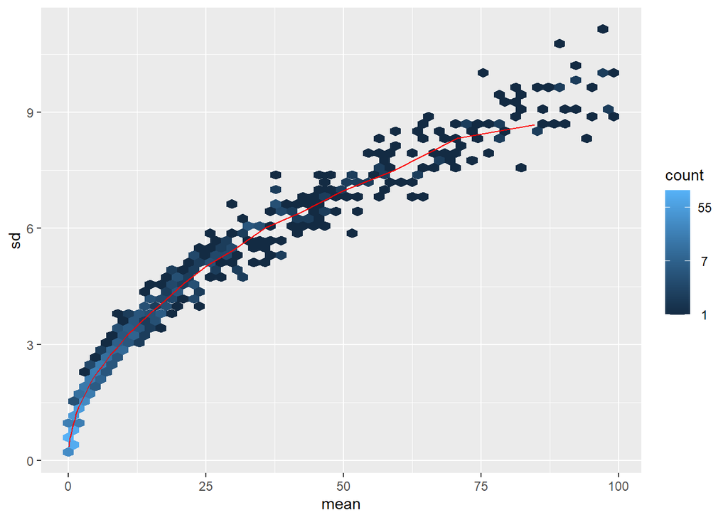

```r
lambda <- 10^seq(from = -1, to = 2, length = 1000)
cts <- matrix(rpois(1000*100, lambda), ncol = 100)
library("vsn")
meanSdPlot(cts, ranks = FALSE)
```

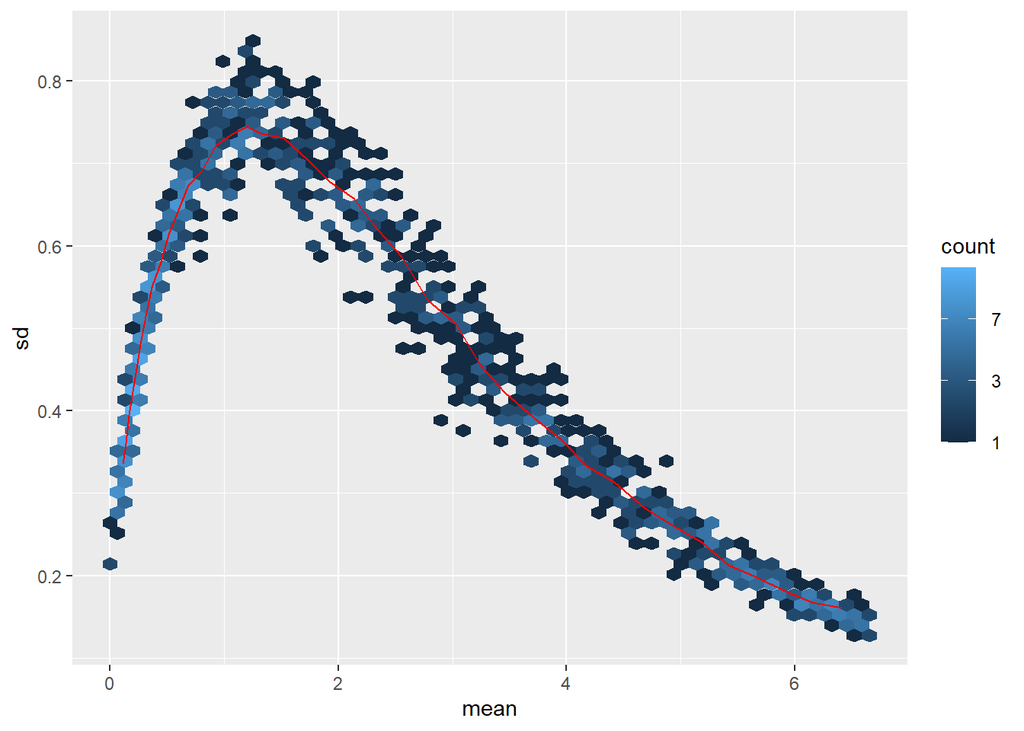

```r
log.cts.one <- log2(cts + 1)
meanSdPlot(log.cts.one, ranks = FALSE)
```

## There are a couple different tarnsformations for variance stabilization, the variance stabilizing transformation (VST) which is for negative binomial data, and the regularized-logarithm transformation (rlog). I have run both, but for our analysis, I used the results of the vst algorithm.

```r
vsd <- vst(dds, blind = FALSE)
head(assay(vsd), 3)
```

```
##           SRR5616889 SRR5616890 SRR5616891 SRR5616892 SRR5616893 SRR5616894
## DDX11L1     3.573693   2.874396   2.874396   3.983360   4.281303   2.874396
## WASH7P      9.428836   9.531773   9.431746   8.992686   9.941183   8.333141
## MIR6859-1   5.826853   6.679993   5.956237   5.166743   6.881935   5.467622
##           SRR5616895 SRR5616896 SRR5616897 SRR5616898 SRR5616899 SRR5616900
## DDX11L1     3.563906   3.681434   3.760840   2.874396   3.632881   3.714357
## WASH7P      8.180802   9.326049   8.781954   8.655441   9.054410   9.559882
## MIR6859-1   5.068175   6.545031   6.235918   6.096630   6.548346   6.021761
##           SRR5616901 SRR5616902 SRR5616903 SRR5616904 SRR5616905 SRR5616906
## DDX11L1     3.971816   4.481073   3.962322   2.874396   4.165067   3.702066
## WASH7P      8.505907   9.048605   8.559735   8.384097   9.233525   8.721624
## MIR6859-1   6.033058   6.217025   5.410890   5.459383   6.312639   5.567766
##           SRR5616907 SRR5616908 SRR5616909 SRR5616910 SRR5616911 SRR5616912
## DDX11L1     3.651969   3.858305   4.239217   2.874396   4.256439   4.028541
## WASH7P      8.642758  10.029302   9.824659   8.944657   8.904461   9.146453
## MIR6859-1   4.462510   7.036056   5.942362   5.918530   5.201620   6.138718
##           SRR5616913 SRR5616914 SRR5616915 SRR5616916 SRR5616917 SRR5616918
## DDX11L1     3.815442   3.765025   2.874396   4.144868   4.191015   4.540857
## WASH7P      9.375591   7.899128   8.943973   9.914237   9.156686   9.564643
## MIR6859-1   6.105004   5.021521   5.726398   6.863234   5.813530   6.165934
##           SRR5616919 SRR5616920 SRR5616921 SRR5616922 SRR5616923 SRR5616924
## DDX11L1     3.454342   4.517557   2.874396   4.411257   4.231536   4.426708
## WASH7P     10.022749   9.128666   9.681295   9.159966   9.537291   9.677650
## MIR6859-1   6.934481   5.440349   6.220011   5.934090   6.647307   6.586453
```

```r
rld <- rlog(dds, blind = FALSE)
```

```
## rlog() may take a few minutes with 30 or more samples,
## vst() is a much faster transformation
```

```r
head(assay(rld), 3)
```

```
##           SRR5616889 SRR5616890 SRR5616891 SRR5616892 SRR5616893 SRR5616894
## DDX11L1     1.668841   1.452537   1.520175   1.923198   2.150747   1.459856
## WASH7P      9.306426   9.378436   9.308102   9.007227   9.668318   8.571326
## MIR6859-1   5.522001   6.162137   5.618269   5.061848   6.311866   5.257917
##           SRR5616895 SRR5616896 SRR5616897 SRR5616898 SRR5616899 SRR5616900
## DDX11L1     1.661974   1.725620   1.788678   1.466872   1.691036   1.760919
## WASH7P      8.474314   9.235169   8.866591   8.781569   9.048799   9.397476
## MIR6859-1   4.975790   6.059591   5.821016   5.721890   6.063684   5.665789
##           SRR5616901 SRR5616902 SRR5616903 SRR5616904 SRR5616905 SRR5616906
## DDX11L1     1.920496   2.345494   1.917116   1.462451   2.075378   1.739983
## WASH7P      8.683588   9.044805   8.718194   8.604251   9.171362   8.825310
## MIR6859-1   5.674495   5.813992   5.213628   5.252460   5.885241   5.331271
##           SRR5616907 SRR5616908 SRR5616909 SRR5616910 SRR5616911 SRR5616912
## DDX11L1     1.721601   1.842223   2.071665   1.456602   2.080849   1.967779
## WASH7P      8.773884   9.731120   9.583540   8.974513   8.948653   9.111604
## MIR6859-1   4.614663   6.423715   5.609564   5.589299   5.119679   5.754097
##           SRR5616913 SRR5616914 SRR5616915 SRR5616916 SRR5616917 SRR5616918
## DDX11L1     1.819674   1.777185   1.458378   2.049759   2.072334   2.344346
## WASH7P      9.268835   8.296839   8.974062   9.649172   9.118606   9.401058
## MIR6859-1   5.725023   4.932640   5.447117   6.299305   5.514153   5.772083
##           SRR5616919 SRR5616920 SRR5616921 SRR5616922 SRR5616923 SRR5616924
## DDX11L1     1.635356   2.268470   1.552944   2.264062   2.098243   2.258043
## WASH7P      9.726362   9.099553   9.482410   9.120853   9.381804   9.480655
## MIR6859-1   6.346147   5.269322   5.808413   5.600996   6.130058   6.086526
```

```r
# Perform the same variance stabilization on the subset after the samples have been removed.
vsd_rm_samples <- vst(dds_rm_samples, blind = FALSE)
head(assay(vsd_rm_samples),3)
```

```
##           SRR5616889 SRR5616890 SRR5616891 SRR5616893 SRR5616894 SRR5616896
## DDX11L1     3.721226   3.064616   3.064616   4.388812   3.064616   3.822794
## WASH7P      9.438132   9.538654   9.437666   9.946688   8.337482   9.336110
## MIR6859-1   5.876234   6.709303   5.999632   6.907671   5.520523   6.578932
##           SRR5616898 SRR5616899 SRR5616900 SRR5616901 SRR5616902 SRR5616904
## DDX11L1     3.064616   3.776536   3.852162   4.093373   4.579347   3.064616
## WASH7P      8.664612   9.063286   9.563200   8.509555   9.057942   8.392514
## MIR6859-1   6.136843   6.580379   6.061735   6.069665   6.256026   5.515747
##           SRR5616905 SRR5616906 SRR5616907 SRR5616908 SRR5616909 SRR5616910
## DDX11L1     4.280135   3.843730   3.794593   3.988358   4.349529   3.064616
## WASH7P      9.244607   8.739397   8.653736  10.033673   9.831917   8.949448
## MIR6859-1   6.351609   5.628881   4.561631   7.058728   5.987935   5.960684
##           SRR5616911 SRR5616912 SRR5616913 SRR5616914 SRR5616915 SRR5616916
## DDX11L1     4.366840   4.148610   3.946844   3.903064   3.064616   4.258990
## WASH7P      8.916723   9.151928   9.377915   7.921278   8.947104   9.918570
## MIR6859-1   5.271267   6.176595   6.141728   5.100556   5.772598   6.888167
##           SRR5616917 SRR5616918 SRR5616919 SRR5616920 SRR5616921 SRR5616922
## DDX11L1     4.301364   4.634142   3.607500   4.614401   3.064616   4.511790
## WASH7P      9.159905   9.568097  10.022907   9.138305   9.683824   9.166587
## MIR6859-1   5.857931   6.202587   6.954838   5.500657   6.254928   5.977924
##           SRR5616923 SRR5616924
## DDX11L1     4.341155   4.526826
## WASH7P      9.542686   9.683478
## MIR6859-1   6.675894   6.616795
```

## Here we take the sample distances between each sample and all the others.

```r
sampleDists <- dist(t(assay(vsd)))
sampleDists
```

```
##            SRR5616889 SRR5616890 SRR5616891 SRR5616892 SRR5616893 SRR5616894
## SRR5616890   80.06706
## SRR5616891   84.90328   81.66588
## SRR5616892   88.58608   86.53925   97.23931
## SRR5616893   71.75765   79.91760   79.08041   92.39089
## SRR5616894   94.17052   78.40677   98.41381   90.95737   99.82751
## SRR5616895  130.39317  109.60895  130.22079   96.32685  131.70817   99.79874
## SRR5616896   82.68250   77.80387   76.89668   93.52221   72.10775   87.46902
## SRR5616897  118.42713  120.04035  127.87220  111.93565  119.91288  128.30833
## SRR5616898   87.38710   72.80519   91.17854   75.79229   87.33234   67.65159
## SRR5616899   82.87124   71.55005   87.94244   89.56750   83.34143   63.66224
## SRR5616900   80.44871   84.20530   85.88755   81.67103   74.75322   95.19827
## SRR5616901   96.53122   88.37530   99.82358   91.27289  101.67771   63.00574
## SRR5616902   78.96499   70.16523   79.86110   84.61012   71.74728   78.73552
## SRR5616903  102.33448   91.95738  106.13498   79.36759  101.31945   88.53227
## SRR5616904   96.02447   79.07579   93.93159   87.50930   91.95030   74.31588
## SRR5616905   88.07443   79.58280   91.61989   85.17438   84.40287   73.02819
## SRR5616906  109.46530   98.66267  115.68857   77.97182  115.71645   97.79466
## SRR5616907  117.68995  123.45892  128.91816  109.83221  122.74303  130.89683
## SRR5616908   69.73565   92.69235   90.70398   91.53419   78.87467  112.03356
## SRR5616909  108.78019  112.16055  119.74513   90.99464  113.47791  120.13179
## SRR5616910   79.45969   69.14936   86.87122   75.01324   84.79079   65.02414
## SRR5616911  117.71448  110.68124  120.87821  105.48320  117.00216  113.57415
## SRR5616912   83.36566   71.21735   84.00245   76.66136   81.96496   70.80528
## SRR5616913   89.35429   90.75835   96.33162   90.37247   83.96339  102.53847
## SRR5616914  133.53878  117.75005  136.48258   97.93968  137.77210  108.19455
## SRR5616915   93.10951   80.30883   97.12062   78.76193   96.89295   62.24031
## SRR5616916   78.94246   73.00090   85.58036   81.25173   77.46737   73.45235
## SRR5616917   81.83698   72.72480   83.72023   72.98921   79.79234   84.03469
## SRR5616918   82.19472   75.20010   86.73782   71.29950   78.08009   83.79031
## SRR5616919   92.52422   96.76439  102.77107   83.26914   92.22742   98.80245
## SRR5616920  118.97634  111.61523  124.27992   93.42817  117.07359  118.05969
## SRR5616921  100.16704  102.67712   99.57878  106.43470   88.12378  119.19810
## SRR5616922   85.08118   74.59276   90.00984   73.41093   86.31236   70.26898
## SRR5616923  100.41681   93.57472  105.56106   84.45347   98.13087   88.34641
## SRR5616924   97.72981   89.24398   97.63810   76.78048   94.25340   91.81031
##            SRR5616895 SRR5616896 SRR5616897 SRR5616898 SRR5616899 SRR5616900
## SRR5616890
## SRR5616891
## SRR5616892
```

[output cut: 161 more lines]

```
## SRR5616910
## SRR5616911
## SRR5616912
## SRR5616913
## SRR5616914
## SRR5616915
## SRR5616916
## SRR5616917
## SRR5616918
## SRR5616919
## SRR5616920  107.03856
## SRR5616921  100.78365  125.26744
## SRR5616922   81.04468   96.79970  101.75637
## SRR5616923   77.49714  100.56797  106.17540   72.05890
## SRR5616924   80.00285  100.62136  103.98801   77.36754   82.47932
```

```r
sampleDists_rm_samples <- dist(t(assay(vsd_rm_samples)))
```

## Here we visualize the differences between samples based on gene expression, and the sample type is on the right side. The samples have been clustered as well.

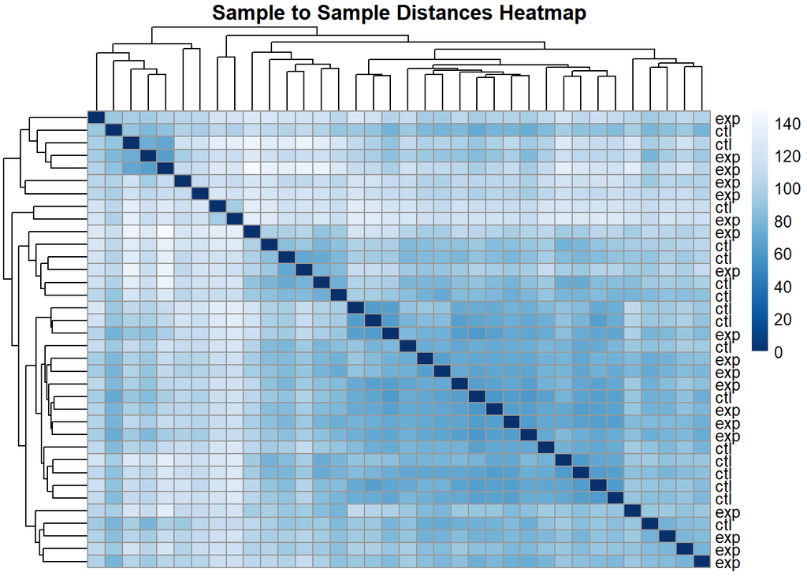

```r
#Plot sample distances.
library("pheatmap")
library("RColorBrewer")

sampleDistMatrix <- as.matrix( sampleDists )
sampleDistMatrix_rm_samples <- as.matrix( sampleDists_rm_samples )

rownames(sampleDistMatrix) <- vsd$condition
colnames(sampleDistMatrix) <- NULL
colors <- colorRampPalette( rev(brewer.pal(9, "Blues")) )(255)
pheatmap(sampleDistMatrix,
         clustering_distance_rows = sampleDists,
         clustering_distance_cols = sampleDists,
         col = colors,
         main = "Sample to Sample Distances Heatmap")
```

## Now we perform PCA on the VST transformed data and plot the first two principal components along with sample type informatin.

```r
# PCA Plot
pcaData <- plotPCA(vsd, intgroup = c( "condition"), returnData = TRUE)
pcaData
```

```
##                    PC1         PC2 group condition       name
## SRR5616889 -22.2035719 -20.9312322   ctl       ctl SRR5616889
## SRR5616890   1.3275864  -8.1547721   ctl       ctl SRR5616890
## SRR5616891  -4.5993161 -15.2132651   ctl       ctl SRR5616891
## SRR5616892 -13.8712395  -3.9049678   ctl       ctl SRR5616892
## SRR5616893  -6.9524601 -17.1427454   ctl       ctl SRR5616893
## SRR5616894  16.9217501  -2.7580301   ctl       ctl SRR5616894
## SRR5616895  11.7158597  16.6710927   ctl       ctl SRR5616895
## SRR5616896  15.7907465  -9.0558324   ctl       ctl SRR5616896
## SRR5616897 -14.7132447   9.1770999   ctl       ctl SRR5616897
## SRR5616898  13.9171270   2.6660372   ctl       ctl SRR5616898
## SRR5616899  19.1151393  -5.6805030   ctl       ctl SRR5616899
## SRR5616900  -9.3170800  -4.8455006   ctl       ctl SRR5616900
## SRR5616901  11.9610957  -5.8857299   ctl       ctl SRR5616901
## SRR5616902  15.1561872  -9.6038952   ctl       ctl SRR5616902
## SRR5616903   2.9393552  16.0326163   ctl       ctl SRR5616903
## SRR5616904  25.1648986   5.5742540   ctl       ctl SRR5616904
## SRR5616905  19.3680933  -4.4630639   ctl       ctl SRR5616905
## SRR5616906 -10.0672502   8.3961832   exp       exp SRR5616906
## SRR5616907 -33.0585287  17.5505103   exp       exp SRR5616907
## SRR5616908 -40.0027293 -17.4878367   exp       exp SRR5616908
## SRR5616909 -29.2923738   8.7876368   exp       exp SRR5616909
## SRR5616910  -1.1031910  -7.8445512   exp       exp SRR5616910
## SRR5616911  -7.1049733  23.1104802   exp       exp SRR5616911
## SRR5616912  11.5164843  -1.9062289   exp       exp SRR5616912
## SRR5616913  -6.3031451  -7.8966706   exp       exp SRR5616913
## SRR5616914  -1.7069618  25.9308324   exp       exp SRR5616914
## SRR5616915  12.4157413  -0.4551195   exp       exp SRR5616915
## SRR5616916   9.1125505   0.1741817   exp       exp SRR5616916
## SRR5616917  -1.5767974  -4.1512735   exp       exp SRR5616917
## SRR5616918  -0.7026727  -3.4820146   exp       exp SRR5616918
## SRR5616919   1.3512711  -4.1053305   exp       exp SRR5616919
## SRR5616920 -10.2829944  19.9133062   exp       exp SRR5616920
## SRR5616921  -1.8258355 -12.6519190   exp       exp SRR5616921
## SRR5616922   2.5940466   4.4137378   exp       exp SRR5616922
## SRR5616923  15.8795222   8.2029690   exp       exp SRR5616923
## SRR5616924   8.4369105   1.0195443   exp       exp SRR5616924
```

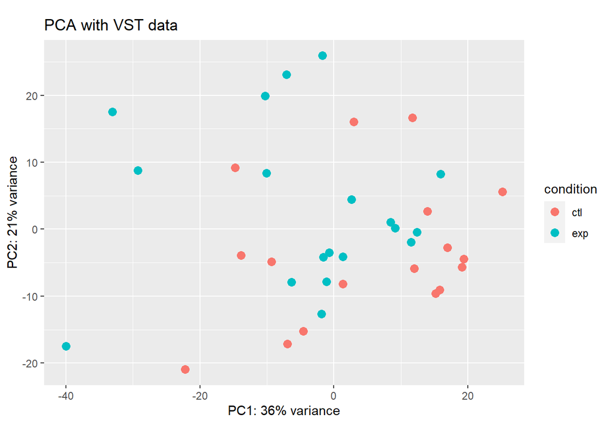

```r
percentVar <- round(100 * attr(pcaData, "percentVar"))
ggplot(pcaData, aes(x = PC1, y = PC2, color = condition)) +
  geom_point(size =3) +
  xlab(paste0("PC1: ", percentVar[1], "% variance")) +
  ylab(paste0("PC2: ", percentVar[2], "% variance")) +
  coord_fixed() +
  ggtitle("PCA with VST data")
```

```r
# PCA Plot after removing samples.
pcaData <- plotPCA(vsd_rm_samples, intgroup = c( "condition"), returnData = TRUE)
pcaData
```

```
##                    PC1          PC2 group condition       name
## SRR5616889 -22.8611561 -20.25446448   ctl       ctl SRR5616889
## SRR5616890   0.9018692  -6.49666048   ctl       ctl SRR5616890
## SRR5616891  -5.0448564 -13.66751307   ctl       ctl SRR5616891
## SRR5616893  -7.2640942 -16.12332686   ctl       ctl SRR5616893
## SRR5616894  16.2213287  -1.65712050   ctl       ctl SRR5616894
## SRR5616896  15.8499758  -6.79047390   ctl       ctl SRR5616896
## SRR5616898  13.3105927   3.76931959   ctl       ctl SRR5616898
## SRR5616899  18.8153936  -3.80310013   ctl       ctl SRR5616899
## SRR5616900  -9.2674847  -3.30226774   ctl       ctl SRR5616900
## SRR5616901  11.7296216  -4.60508357   ctl       ctl SRR5616901
## SRR5616902  14.6476626  -8.27045146   ctl       ctl SRR5616902
## SRR5616904  24.7690562   7.22635114   ctl       ctl SRR5616904
## SRR5616905  19.2264978  -3.05374943   ctl       ctl SRR5616905
## SRR5616906 -10.7958118   8.48223280   exp       exp SRR5616906
## SRR5616907 -33.0117158  16.81096864   exp       exp SRR5616907
## SRR5616908 -40.7928212 -17.25487766   exp       exp SRR5616908
## SRR5616909 -29.8233955  10.03244033   exp       exp SRR5616909
## SRR5616910  -1.4743750  -6.97329281   exp       exp SRR5616910
## SRR5616911  -7.8945990  25.04957598   exp       exp SRR5616911
## SRR5616912  11.1538162  -0.68625090   exp       exp SRR5616912
## SRR5616913  -6.3648072  -6.47050111   exp       exp SRR5616913
## SRR5616914  -2.6913342  26.11863266   exp       exp SRR5616914
## SRR5616915  11.6218664   0.08757971   exp       exp SRR5616915
## SRR5616916   8.6549631   1.55507573   exp       exp SRR5616916
## SRR5616917  -2.0781814  -3.17402711   exp       exp SRR5616917
## SRR5616918  -1.1072850  -2.27206992   exp       exp SRR5616918
## SRR5616919   1.2489456  -2.60991980   exp       exp SRR5616919
## SRR5616920 -11.1540784  20.82505851   exp       exp SRR5616920
## SRR5616921  -2.1411473 -10.97594816   exp       exp SRR5616921
## SRR5616922   1.9373582   5.71396347   exp       exp SRR5616922
## SRR5616923  15.7335922  10.13596233   exp       exp SRR5616923
## SRR5616924   7.9446033   2.63393820   exp       exp SRR5616924
```

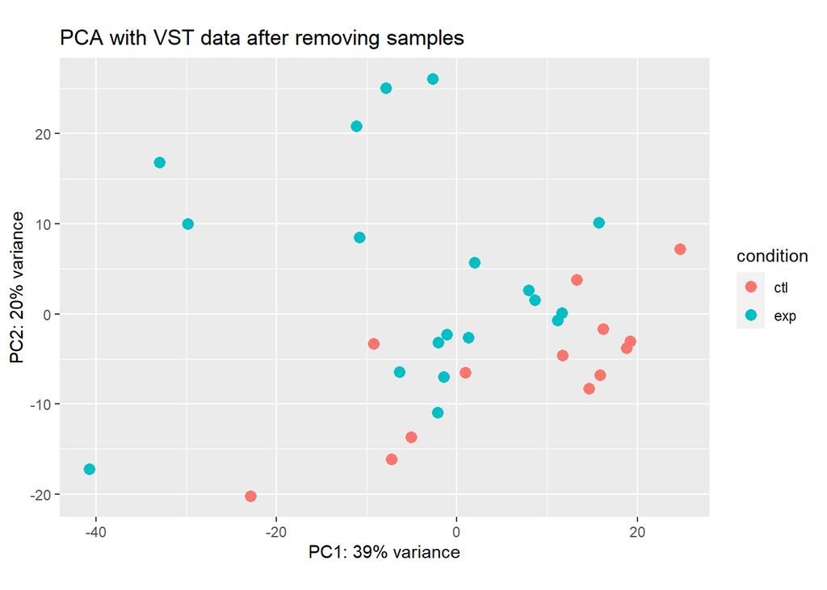

```r
percentVar <- round(100 * attr(pcaData, "percentVar"))
ggplot(pcaData, aes(x = PC1, y = PC2, color = condition)) +
  geom_point(size =3) +
  xlab(paste0("PC1: ", percentVar[1], "% variance")) +
  ylab(paste0("PC2: ", percentVar[2], "% variance")) +
  coord_fixed() +
  ggtitle("PCA with VST data after removing samples")
```

Here we plot the MDS plot, similar to the PCA plot.

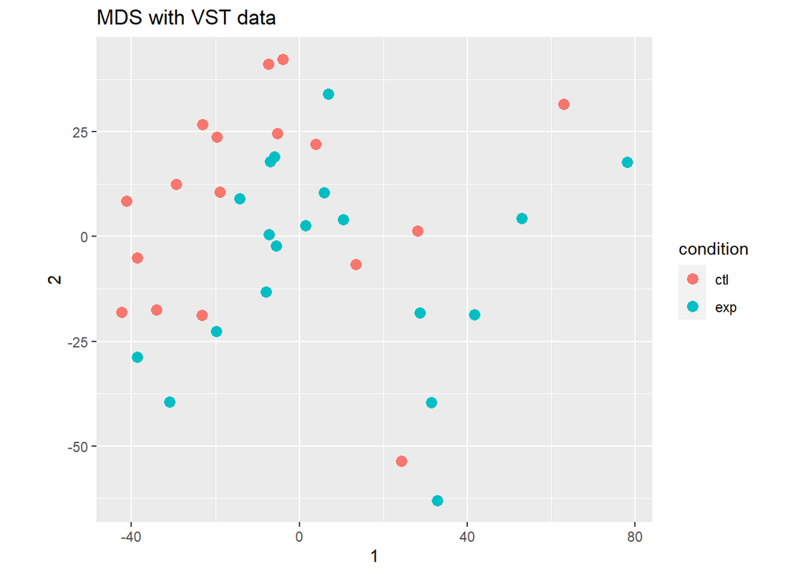

```r
mds <- as.data.frame(colData(vsd))  %>%
         cbind(cmdscale(sampleDistMatrix))
ggplot(mds, aes(x = `1`, y = `2`, color = condition)) +
  geom_point(size = 3) + coord_fixed() + ggtitle("MDS with VST data")
```

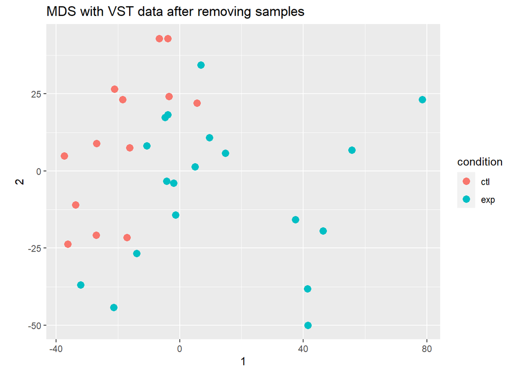

```r
mds <- as.data.frame(colData(vsd_rm_samples))  %>%
         cbind(cmdscale(sampleDistMatrix_rm_samples))
ggplot(mds, aes(x = `1`, y = `2`, color = condition)) +
  geom_point(size = 3) + coord_fixed() + ggtitle("MDS with VST data after removing samples")
```

## Now we perform the actual DESeq analysis and store the results.

```r
dds <- DESeq(dds)
```

```
## -- replacing outliers and refitting for 216 genes
## -- DESeq argument 'minReplicatesForReplace' = 7
## -- original counts are preserved in counts(dds)
```

```r
res <- results(dds)
res
```

```
## log2 fold change (MLE): condition exp vs ctl
## Wald test p-value: condition exp vs ctl
## DataFrame with 22751 rows and 6 columns
##                      baseMean      log2FoldChange             lfcSE
##                     <numeric>           <numeric>         <numeric>
## DDX11L1      4.02629388266831   0.694595314768056 0.464218956295729
## WASH7P       589.856243654455   0.294487740120152 0.172363489304181
## MIR6859-1      55.17843071747  0.0504163281416481  0.23721608003793
## MIR1302-2HG  7.42711854751795 -0.0930112362910303 0.346399723089453
## LOC100996442 522.365956707189  -0.267761180097566 0.140699145273162
## ...                       ...                 ...               ...
## LOC105377237 2.75567376686528  -0.638434341812868 0.380136574667464
## REREP1Y      10.8317119202234    0.14258863586831 0.234864272084842
## GOLGA2P2Y    5.23049004655878   0.534137623187924 0.566546891812466
## GOLGA2P3Y    3.71885706150983   0.384480251314202 0.572646378784686
## REREP2Y      11.0708259244492   0.199468000153923 0.232403466642546
##                            stat             pvalue              padj
##                       <numeric>          <numeric>         <numeric>
## DDX11L1        1.49626659003896  0.134584197799525 0.516414472255801
## WASH7P         1.70852737612228 0.0875385311626368 0.444737421210015
## MIR6859-1     0.212533349904385  0.831690962558362 0.952073517325664
## MIR1302-2HG  -0.268508402551498  0.788308007969416 0.936510120485209
## LOC100996442  -1.90307609600412 0.0570306165534005 0.386814306426328
## ...                         ...                ...               ...
## LOC105377237  -1.67948675386302 0.0930572182853922                NA
## REREP1Y       0.607110798941789  0.543777384033416 0.837773049935458
## GOLGA2P2Y     0.942795081761264   0.34578572787402 0.721238415499316
## GOLGA2P3Y     0.671409556679946   0.50195965852859                NA
## REREP2Y       0.858283239211401   0.39073608217668 0.750918477782237
```

```r
dds_rm_samples <- DESeq(dds_rm_samples)
```

```
## -- replacing outliers and refitting for 179 genes
## -- DESeq argument 'minReplicatesForReplace' = 7
## -- original counts are preserved in counts(dds)
```

```r
res_rm_samples <- results(dds_rm_samples)
res_rm_samples
```

```
## log2 fold change (MLE): condition exp vs ctl
## Wald test p-value: condition exp vs ctl
## DataFrame with 22751 rows and 6 columns
##                      baseMean     log2FoldChange             lfcSE
##                     <numeric>          <numeric>         <numeric>
## DDX11L1      4.11530479464193  0.748468879163716 0.528027631664457
## WASH7P       615.592823489417  0.182460060820068  0.18232026318321
## MIR6859-1    57.9588332111077 -0.111367441375887 0.241616809684487
## MIR1302-2HG  7.17841447152194 0.0162773272529046 0.346531858106655
## LOC100996442 536.748418859588  -0.38719452381612  0.14336927776304
## ...                       ...                ...               ...
## LOC105377237 2.86977919650578 -0.809668120375678 0.396725302063334
## REREP1Y      10.4261898311637   0.32118584525754 0.258662696959035
## GOLGA2P2Y     5.6711291746655  0.298684257953622 0.578928176107263
## GOLGA2P3Y    3.93197919839637  0.232490319461485 0.589203847070015
## REREP2Y      10.7050793195884  0.377273415955568 0.254924310838681
##                            stat              pvalue               padj
##                       <numeric>           <numeric>          <numeric>
## DDX11L1        1.41748051480636   0.156342487280041                 NA
## WASH7P         1.00076676960869   0.316939578530602  0.561490488570792
## MIR6859-1    -0.460925883101075   0.644851781188887  0.820267577852461
## MIR1302-2HG  0.0469720946923581   0.962535468180517  0.985929428043925
## LOC100996442  -2.70067987966064 0.00691979064169093 0.0490496911995561
## ...                         ...                 ...                ...
## LOC105377237  -2.04087845207922  0.0412629101117915                 NA
## REREP1Y        1.24171691176794   0.214341027986027  0.449508066690406
## GOLGA2P2Y     0.515926275970859   0.605905901321804  0.795747244034908
## GOLGA2P3Y     0.394583844992882   0.693150037937796                 NA
## REREP2Y        1.47994286898087   0.138888493901058  0.346085978402802
```

```r
res <- results(dds, contrast=c("condition","exp","ctl"))
mcols(res, use.names = TRUE)
```

```
## DataFrame with 6 rows and 2 columns
##                        type                                  description
##                 <character>                                  <character>
## baseMean       intermediate    mean of normalized counts for all samples
## log2FoldChange      results log2 fold change (MLE): condition exp vs ctl
## lfcSE               results         standard error: condition exp vs ctl
## stat                results         Wald statistic: condition exp vs ctl
## pvalue              results      Wald test p-value: condition exp vs ctl
## padj                results                         BH adjusted p-values
```

```r
summary(res)
```

```
##
## out of 22751 with nonzero total read count
## adjusted p-value < 0.1
## LFC > 0 (up)       : 20, 0.088%
## LFC < 0 (down)     : 7, 0.031%
## outliers [1]       : 0, 0%
## low counts [2]     : 2647, 12%
## (mean count < 4)
## [1] see 'cooksCutoff' argument of ?results
## [2] see 'independentFiltering' argument of ?results
```

```r
res_rm_samples <- results(dds_rm_samples, contrast=c("condition","exp","ctl"))
mcols(res_rm_samples, use.names = TRUE)
```

```
## DataFrame with 6 rows and 2 columns
##                        type                                  description
##                 <character>                                  <character>
## baseMean       intermediate    mean of normalized counts for all samples
## log2FoldChange      results log2 fold change (MLE): condition exp vs ctl
## lfcSE               results         standard error: condition exp vs ctl
## stat                results         Wald statistic: condition exp vs ctl
## pvalue              results      Wald test p-value: condition exp vs ctl
## padj                results                         BH adjusted p-values
```

```r
summary(res_rm_samples)
```

```
##
## out of 22751 with nonzero total read count
## adjusted p-value < 0.1
## LFC > 0 (up)       : 2654, 12%
## LFC < 0 (down)     : 1377, 6.1%
## outliers [1]       : 0, 0%
## low counts [2]     : 3088, 14%
## (mean count < 4)
## [1] see 'cooksCutoff' argument of ?results
## [2] see 'independentFiltering' argument of ?results
```

```r
res.05 <- results(dds, alpha = 0.05)
table(res.05$padj < 0.05)
```

```
##
## FALSE  TRUE
## 22745     6
```

```r
res_rm_samples.05 <- results(dds_rm_samples, alpha = 0.001)
table(res_rm_samples.05$padj < 0.001)
```

```
##
## FALSE  TRUE
## 15618   516
```